# HW2_1

Maria Firulyova

```r
library(data.table)
library(dplyr)
library(magrittr)
library(ggplot2)
library(tidyr)
library(plyr)
```

## 1

Import data, transform it to the long format

```r
set.seed(1)
df <- get(data("anscombe"))
df <- data.frame(
  group  = rep(1:4, each = 11),
  x = unlist(df[,c(1:4)]),
  y = unlist(df[,c(5:8)])
)
rownames(df) <- NULL
knitr::kable(head(df))
```

| group | x | y |
| --- | --- | --- |
| 1 | 10 | 8.04 |
| 1 | 8 | 6.95 |
| 1 | 13 | 7.58 |
| 1 | 9 | 8.81 |
| 1 | 11 | 8.33 |
| 1 | 14 | 9.96 |

Plots

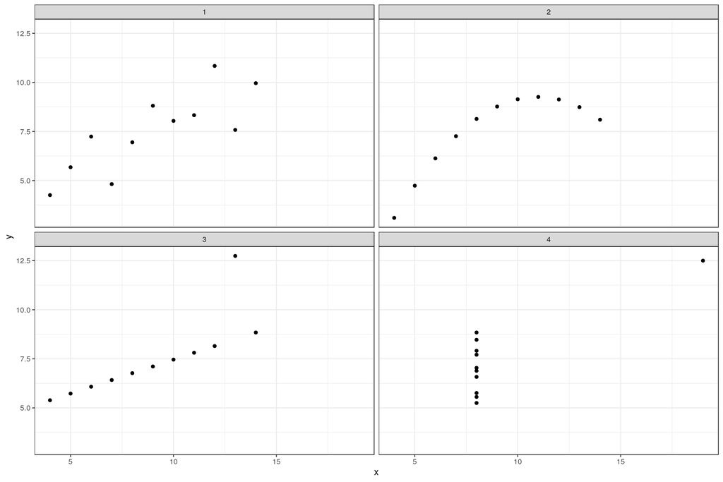

```r
ggplot(data = df, aes(x = x, y = y))+
  geom_point()+
  facet_wrap(~ group)+
  theme_bw()
```

Summary (mean, sd)

```r
knitr::kable(
  df %>% group_by(group) %>%
  summarise_each(list(mean = mean, sd = sd))
)
```

| group | x_mean | y_mean | x_sd | y_sd |
| --- | --- | --- | --- | --- |
| 1 | 9 | 7.500909 | 3.316625 | 2.031568 |
| 2 | 9 | 7.500909 | 3.316625 | 2.031657 |
| 3 | 9 | 7.500000 | 3.316625 | 2.030424 |
| 4 | 9 | 7.500909 | 3.316625 | 2.030578 |

Check whether both *x* and *y* values are normal distributed or not, perform both Pearson and Spearman correlations.

```r
cor_estimate <- function(data)
{
  apply(data.frame(SHAPIRO_X_P_VALUE = shapiro.test(data$x)$p.value,
             SHAPIRO_Y_P_VALUE = shapiro.test(data$y)$p.value,
             PEARSON = cor(data$x, data$y, method = "pearson"),
             PEARSON_P_VALUE = cor.test(data$x, data$y)$p.value,
             SPEARMAN = cor(data$x, data$y, method = "spearman"),
             SPEARMAN_P_VALUE = cor.test(data$x, data$y)$p.value), 2, function(x) round(x, 3))
}

knitr::kable(ddply(df, .(group), cor_estimate))
```

| group | SHAPIRO_X_P_VALUE | SHAPIRO_Y_P_VALUE | PEARSON | PEARSON_P_VALUE | SPEARMAN | SPEARMAN_P_VALUE |
| --- | --- | --- | --- | --- | --- | --- |
| 1 | 0.87 | 0.947 | 0.816 | 0.002 | 0.818 | 0.002 |
| 2 | 0.87 | 0.022 | 0.816 | 0.002 | 0.691 | 0.002 |
| 3 | 0.87 | 0.026 | 0.816 | 0.002 | 0.991 | 0.002 |
| 4 | 0.00 | 0.091 | 0.817 | 0.002 | 0.500 | 0.002 |

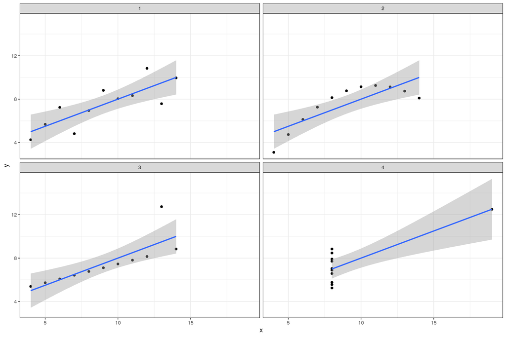

```r
ggplot(data = df, aes(x = x, y = y))+
  geom_point()+
  geom_smooth(method = 'lm')+
  facet_wrap(~ group)+
  theme_bw()
```

## 2

Import data, check *NA* percentage in each column, transform Date from character to factor.

```r
set.seed(1)
air_q <- fread('~/Загрузки/AirQualityUCI.csv', dec=',') %>% select(-c('V16', 'V17'))
air_q <- air_q %>%
  mutate(Date = as.factor(Date)) %>%
  mutate(Time = as.factor(Time))
knitr::kable(apply(air_q, 2, function(x) round(sum(is.na(x)) / length(x), 2)) %>%
               as.data.frame() %>% magrittr::set_colnames('na_percentage'))
```

|  | na_percentage |
| --- | --- |
| Date | 0.00 |
| Time | 0.00 |
| CO(GT) | 0.01 |
| PT08.S1(CO) | 0.01 |
| NMHC(GT) | 0.01 |
| C6H6(GT) | 0.01 |
| PT08.S2(NMHC) | 0.01 |
| NOx(GT) | 0.01 |
| PT08.S3(NOx) | 0.01 |
| NO2(GT) | 0.01 |
| PT08.S4(NO2) | 0.01 |
| PT08.S5(O3) | 0.01 |
| T | 0.01 |
| RH | 0.01 |
| AH | 0.01 |

Since there are not so many *NA* in each column, I can drop it.

```r
air_q <- air_q %>% drop_na()
air_q_long <- air_q %>% melt()
```

Distribution of numeric variables:

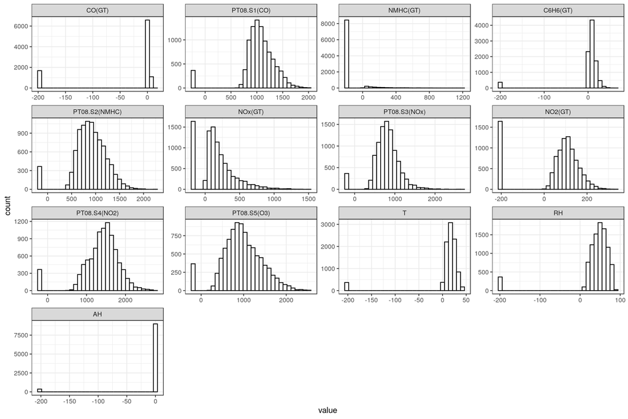

```r
ggplot(air_q_long, aes(x = value))+
  geom_histogram(col = 'black', fill='white')+
  theme_bw()+
  facet_wrap(~variable, scales = 'free')
```

Since there are some negative values (e.g., see *GO(GT)*), I’ll replace it to *NA*.

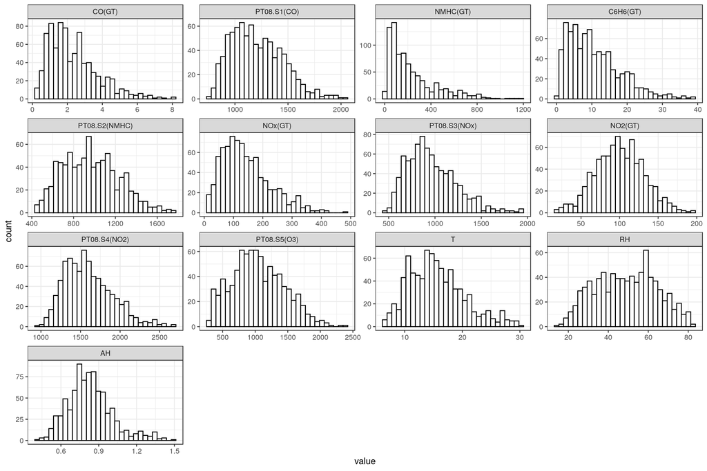

```r
air_q <- sapply(select_if(air_q, is.numeric),
                function(x) ifelse (x < 0, NA, x)) %>%
  as.data.frame() %>%
  drop_na()

air_q_long <- air_q %>% melt()
ggplot(air_q_long, aes(x = value))+
  geom_histogram(col = 'black', fill='white')+
  theme_bw()+
  facet_wrap(~variable, scales = 'free')
```

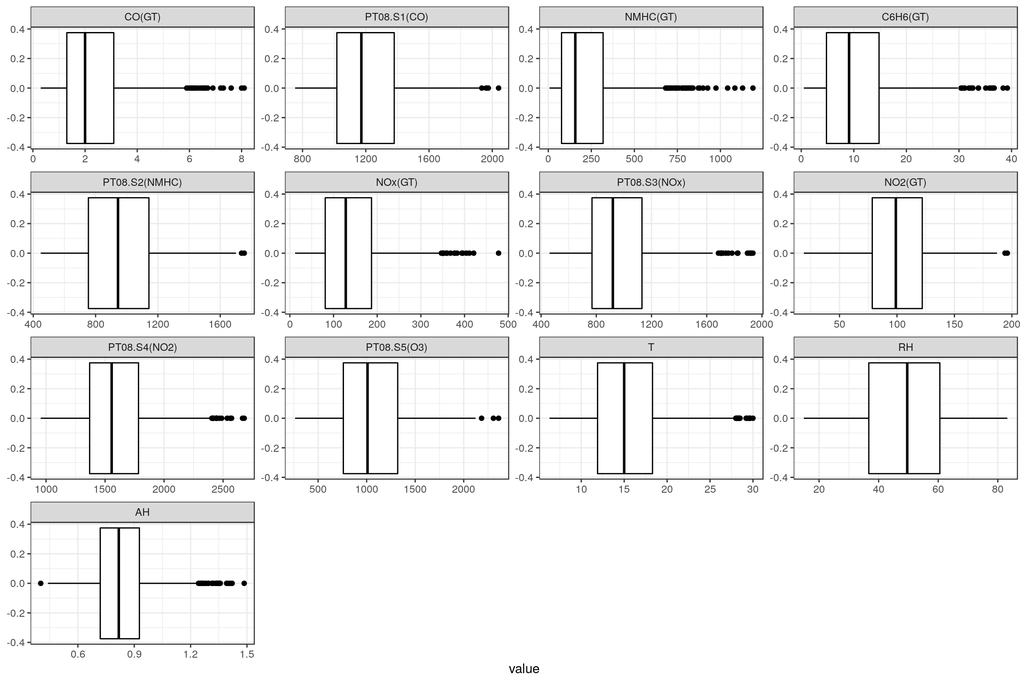

```r
ggplot(air_q_long, aes(x = value))+
  geom_boxplot(col = 'black', fill='white')+
  theme_bw()+
  facet_wrap(~variable, scales = 'free')
```

Let’s check the normality of each numeric variable using Shapiro test. p-values are:

```r
knitr::kable(apply(air_q, 2, function(x) shapiro.test(x)$p.value))
```

|  | x |
| --- | --- |
| CO(GT) | 0.0000000 |
| PT08.S1(CO) | 0.0000000 |
| NMHC(GT) | 0.0000000 |
| C6H6(GT) | 0.0000000 |
| PT08.S2(NMHC) | 0.0000000 |
| NOx(GT) | 0.0000000 |
| PT08.S3(NOx) | 0.0000000 |
| NO2(GT) | 0.4872237 |
| PT08.S4(NO2) | 0.0000000 |
| PT08.S5(O3) | 0.0000002 |
| T | 0.0000000 |
| RH | 0.0000000 |
| AH | 0.0000000 |

There is only one normally distributed variable: *NO2(GT)*.

Let’s investigate correlation matris using Spearman criterion

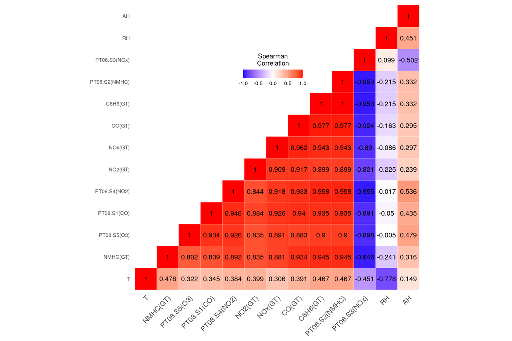

```r
get_upper_tri <- function(cormat){
  cormat[lower.tri(cormat)]<- NA
  cormat
}

reorder_cormat <- function(cormat){
  dd <- as.dist((1-cormat)/2)
  hc <- hclust(dd)
  cormat <-cormat[hc$order, hc$order]
}

cor_mat <- cor(air_q, use = "complete.obs", method = "spearman")
cor_mat <- reorder_cormat(cor_mat)
upper_tri <- get_upper_tri(cor_mat)
melted_cormat <- melt(upper_tri, na.rm = TRUE) %>% mutate(value = round(value, 3))
ggheatmap <- ggplot(melted_cormat, aes(Var2, Var1, fill = value))+
  geom_tile(color = "white")+
  scale_fill_gradient2(low = "blue", high = "red", mid = "white",
                       midpoint = 0, limit = c(-1,1), space = "Lab",
                       name="Spearman\nCorrelation") +
  theme_minimal()+
  theme(axis.text.x = element_text(angle = 45, vjust = 1,
                                   size = 12, hjust = 1))+
  coord_fixed()
ggheatmap+
  geom_text(aes(Var2, Var1, label = value), color = "black", size = 4) +
  theme(
    axis.title.x = element_blank(),
    axis.title.y = element_blank(),
    panel.grid.major = element_blank(),
    panel.border = element_blank(),
    panel.background = element_blank(),
    axis.ticks = element_blank(),
    legend.justification = c(1, 0),
    legend.position = c(0.6, 0.7),
    legend.direction = "horizontal")+
  guides(fill = guide_colorbar(barwidth = 7, barheight = 1,
                               title.position = "top", title.hjust = 0.5))
```

Let’s build some regression models:

Positive correlation:

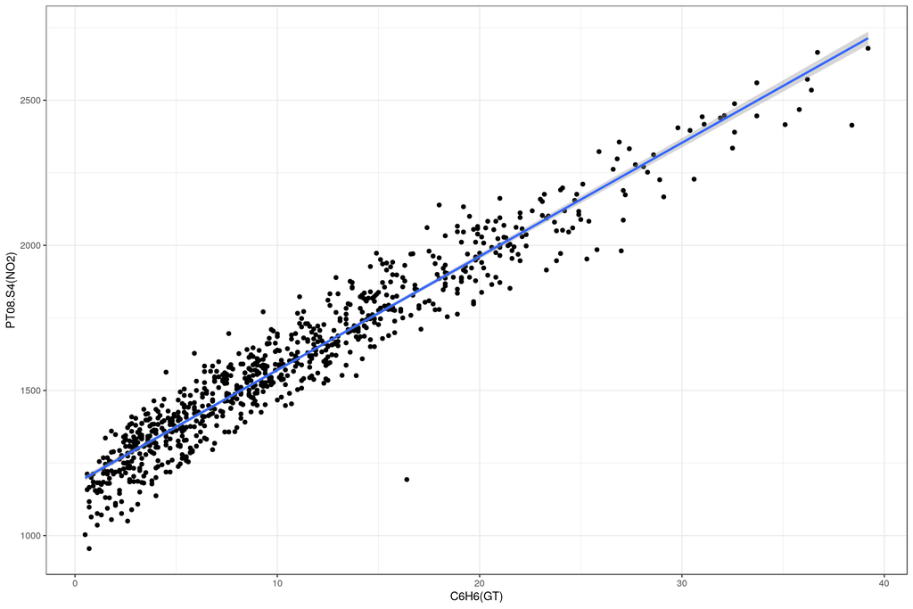

```r
ggplot(air_q, aes(x = `C6H6(GT)`, y = `PT08.S4(NO2)`))+
  geom_point()+
  geom_smooth(method = lm)+
  theme_bw()
```

Negative correlation:

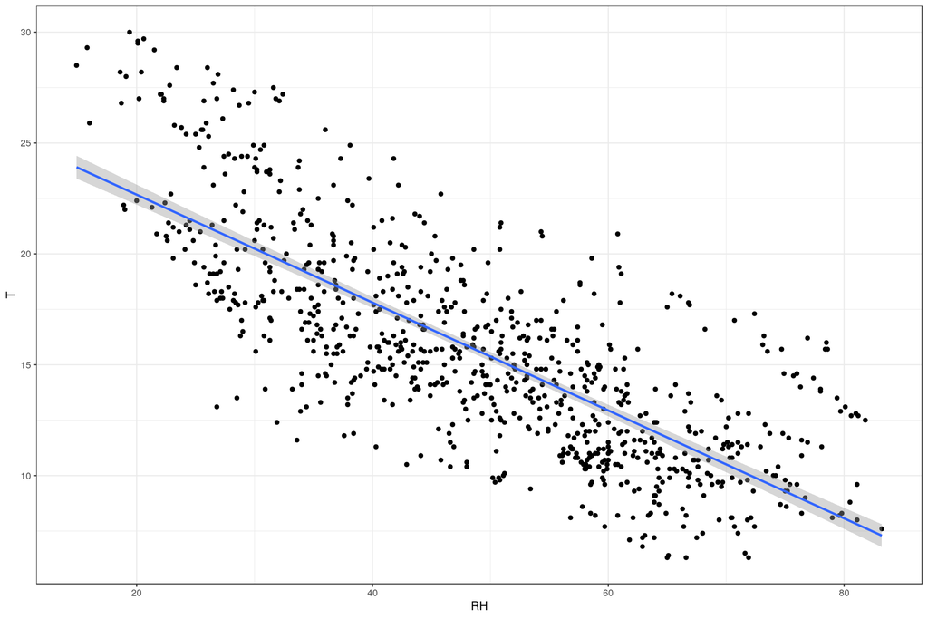

```r
ggplot(air_q, aes(x = `RH`, y = `T`))+
    geom_point()+
    geom_smooth(method = lm)+
    theme_bw()
```

Let’s investigate *R* and *T* dependency

```r
set.seed(1)
fit1 <- lm(RH ~ T, air_q)
summary(fit1)
```

```
##
## Call:
## lm(formula = RH ~ T, data = air_q)
##
## Residuals:
##      Min       1Q   Median       3Q      Max
## -28.3432  -6.3673  -0.0992   5.8855  30.4206
##
## Coefficients:
##             Estimate Std. Error t value Pr(>|t|)
## (Intercept)  87.0519     1.1480   75.83   <2e-16 ***
## T            -2.4358     0.0703  -34.65   <2e-16 ***
## ---
## Signif. codes:  0 '***' 0.001 '**' 0.01 '*' 0.05 '.' 0.1 ' ' 1
##
## Residual standard error: 9.749 on 825 degrees of freedom
## Multiple R-squared:  0.5927, Adjusted R-squared:  0.5922
## F-statistic:  1201 on 1 and 825 DF,  p-value: < 2.2e-16
```

What if we transform our variables?

```r
set.seed(1)
fit2 <- lm(log10(RH) ~ log10(T), air_q)
summary(fit2)
```

```
##
## Call:
## lm(formula = log10(RH) ~ log10(T), data = air_q)
##
## Residuals:
##       Min        1Q    Median        3Q       Max
## -0.285758 -0.058287  0.003045  0.061079  0.254641
##
## Coefficients:
##             Estimate Std. Error t value Pr(>|t|)
## (Intercept)  2.66155    0.02879   92.45   <2e-16 ***
## log10(T)    -0.84819    0.02439  -34.77   <2e-16 ***
## ---
## Signif. codes:  0 '***' 0.001 '**' 0.01 '*' 0.05 '.' 0.1 ' ' 1
##
## Residual standard error: 0.09469 on 825 degrees of freedom
## Multiple R-squared:  0.5944, Adjusted R-squared:  0.5939
## F-statistic:  1209 on 1 and 825 DF,  p-value: < 2.2e-16
```

Both models gives significant p-values, however the transformed model has greater adjusted R-squared. If our aim is to use model for prediction purposes, the second one is better than the first one.

```r
vals <- cbind(fit2$residuals, fit2$fitted.values) %>% as.data.frame() %>% magrittr::set_colnames(c('residuals', 'fitted'))
knitr::kable(apply(vals, 2, function(x) shapiro.test(x)$p.value))
```

|  | x |
| --- | --- |
| residuals | 0.0064889 |
| fitted | 0.0027915 |

P-values tell us that residuals are not normally distributed, even the histogram looks like normal. Probably, we should bootstrapped our values to give better coeffecients

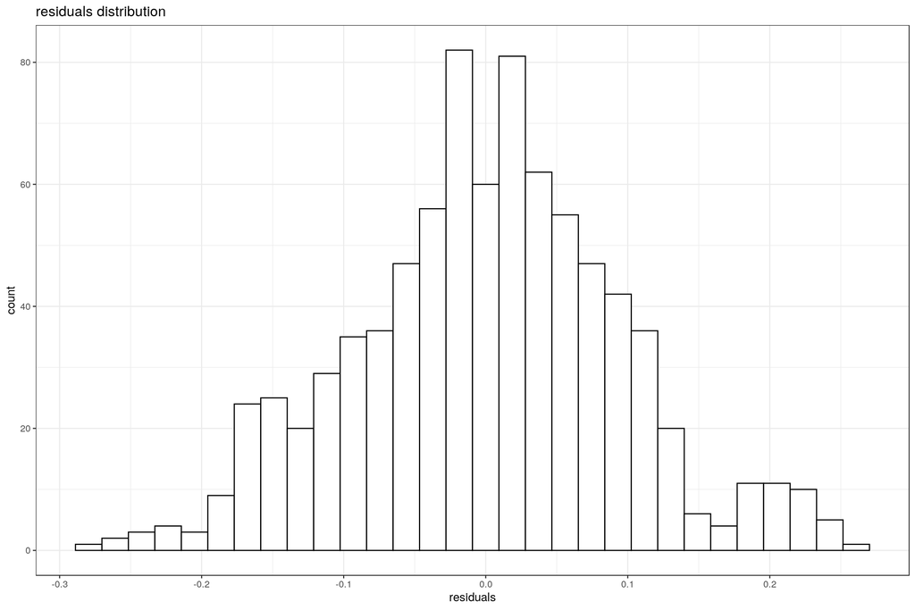

```r
ggplot(vals, aes(x = residuals))+
  geom_histogram(col = 'black', fill='white')+
  theme_bw()+
  ggtitle('residuals distribution')
```

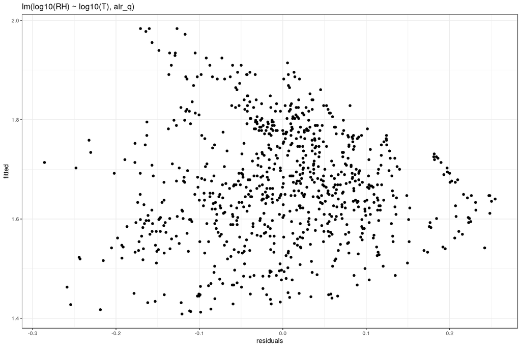

```r
ggplot(vals, aes(x = residuals, y = fitted))+
  geom_point()+
  theme_bw()+
  ggtitle('lm(log10(RH) ~ log10(T), air_q)')
```

```r
set.seed(1)
slope_cl_boot <- function(df) {
  slope <- lm(formula = y ~ x, df)$coefficients[2]
  lm_repl <- replicate(1e3, dplyr::sample_n(df, nrow(df), replace = T), simplify=FALSE)
  lm_repl <- lapply(lm_repl, function(data) lm(formula = y ~ x, data))
  res <- slope - sapply(lm_repl, function(x) x[[1]][2])
  rbind(c(res[50] + slope, res[950] + slope)) %>% as.data.frame() %>%
    magrittr::set_colnames(c('slope_5', 'slope_95'))
}
knitr::kable(slope_cl_boot(air_q %>% select(RH, T) %>% magrittr::set_colnames(c('x', 'y'))))
```

| slope_5 | slope_95 |
| --- | --- |
| -0.2367331 | -0.2393412 |